# Trace Assignment 3

Trace Martin

March 5th, 2023

Lets **scale** up from a single car to a group of cars on a highway and use our **autopower** function to estimate a distribution of power

What might vary?

# Our highway

Mean highway speed is 80 km/hr

```r
#Defining function b/c there was an error and it couldn't find my function even after I reset the working directory. So I put it straight in the code.
autopower = function(V, m, A, cdrag=0.3, crolling=0.015,pair=1.2,g=9.8) {
  P = crolling*m*g*V + 1/2*A*pair*cdrag*V**3
  return(P)
}
```

```r
# generate a structure to store info on our possible cars
#added Car "S" which stands for super light
possible_cars = data.frame(name = c("A","B","C","S"),mass=c(10000,65000,38000,5000), area = c(22,30,22,10))

# here's the speed conversion from kmh to m/s
speed_base = 80 * 0.28

# because I have one mass and area for each car and only 1 speed
# I can estimate power for each car type
# add to the data structure
possible_cars$power = autopower(V=speed_base, A = possible_cars$area, m=possible_cars$mass)

head(possible_cars)
```

```
##   name  mass area     power
## 1    A 10000   22  77436.12
## 2    B 65000   30 274724.89
## 3    C 38000   22 169634.52
## 4    S  5000   10  36694.96
```

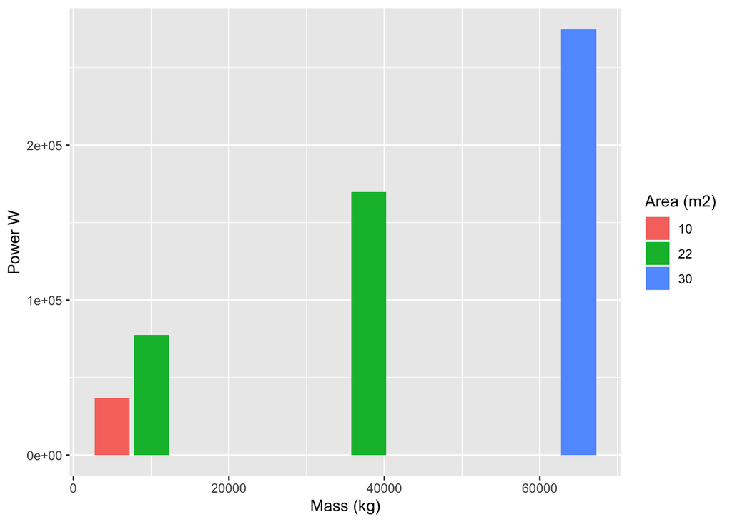

```r
# show results
ggplot(possible_cars, aes(x=mass, y=power, fill=as.factor(area)))+geom_col()+labs(y="Power W", x="Mass (kg)", fill="Area (m2)")
```

# Building a highway

What could be the total power consumed if there are 100 cars on this highway each hour, they are travelling at a range of speeds - mean is 100km/hr and speeds tend to be log-normally distributed)

How would the total power consumed vary by car So if all cars are car A; OR all cars are car B OR all cars are car C

We will use *sample* here to generate speeds for our 100 cars and look at different ways to repeat power calculation for different cars

- repeating by hand
- *pmap* for repetition - a efficient way of looping in R
- *for* for repetition - a more standard way of looping available in many langugaes

# First lets do it ‘by hand’

```r
# what is I want to estimate average power use given  each car

possible_cars
```

```
##   name  mass area     power
## 1    A 10000   22  77436.12
## 2    B 65000   30 274724.89
## 3    C 38000   22 169634.52
## 4    S  5000   10  36694.96
```

```r
# use sample to generate a distribution of speeds

# assume a log normal distribution of speeds with mean 80km/hr, and standard deviation that is 10% of the mean

# recall our function needs speed in m/s not km/hr so we will also do a conversion
# lets get a sample of a 200 speeds- we could also do this by actually measuring speeds

nsample = 200
mean_speed = log(100*0.277)

speeds = rlnorm(mean=mean_speed, sd=0.1*mean_speed, nsample)
summary(speeds)
```

```
##    Min. 1st Qu.  Median    Mean 3rd Qu.    Max.
##   12.36   21.10   26.72   27.81   33.27   62.92
```

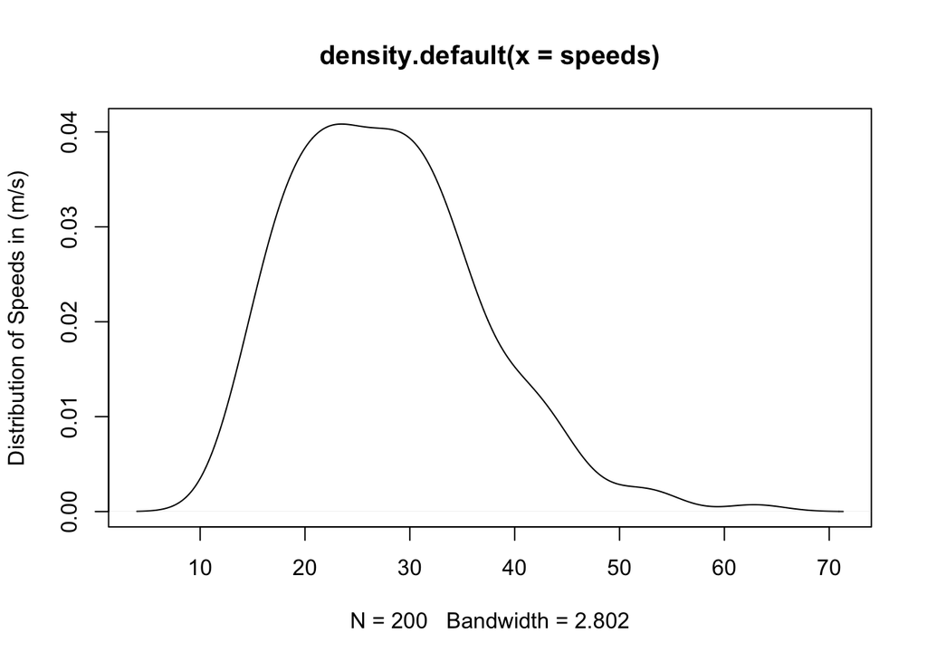

```r
plot(density(speeds), ylab="Distribution of Speeds in (m/s)")
```

```r
# how do we run each car for all speeds

# first lets to it by hand for the first car - the first row in our possible cars matrix
possible_cars[1,]
```

```
##   name  mass area    power
## 1    A 10000   22 77436.12
```

```r
# we could do it by hand
powerA = autopower(V=speeds, A = possible_cars$area[1], m=possible_cars$mass[1])
summary(powerA)
```

```
##    Min. 1st Qu.  Median    Mean 3rd Qu.    Max.
##   25661   68227  114802  154729  194677 1078780
```

```r
# next car (row 2)
powerB = autopower(V=speeds, A = possible_cars$area[2], m=possible_cars$mass[2])
summary(powerB)
```

```
##    Min. 1st Qu.  Median    Mean 3rd Qu.    Max.
##  128350  252362  358278  420998  516640 1946118
```

```r
# next car (row 3)
powerC = autopower(V=speeds, A = possible_cars$area[3], m=possible_cars$mass[3])
summary(powerC)
```

```
##    Min. 1st Qu.  Median    Mean 3rd Qu.    Max.
##   76554  155080  224771  269209  331599 1337748
```

```r
# next car (row 4)
powerS = autopower(V=speeds, A = possible_cars$area[4], m=possible_cars$mass[4])
# look what I got
summary(powerS)
```

```
##    Min. 1st Qu.  Median    Mean 3rd Qu.    Max.
##   12490   32422   53968   72190   90712  494559
```

```r
# we could put this together
powerall1 = cbind.data.frame(powerA, powerB, powerC, powerS)
colnames(powerall1)=possible_cars$name


# for plotting sometimes its useful to turn columns in to rows - we can use an R function
# called pivot_longer (part of the tidyverse package) to do this
# compare powerall1 and powerallr1 to see what pivot_longer does
powerallr1 = powerall1 %>% pivot_longer(cols=everything(), names_to="car", values_to="power")
head(powerallr1)
```

```
## # A tibble: 6 × 2
##   car     power
##   <chr>   <dbl>
## 1 A     204640.
## 2 B     535280.
## 3 C     344317.
## 4 S      95286.
## 5 A     137052.
## 6 B     404422.
```

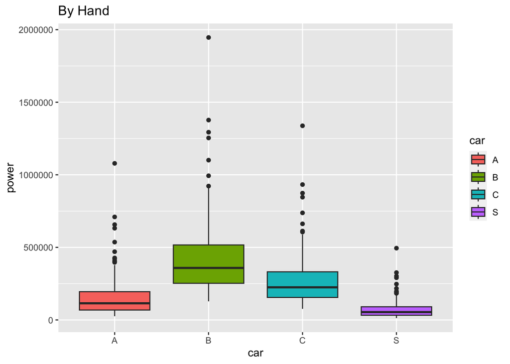

```r
# quick visualization
# lets save it so that we can compare
method1_plot = ggplot(powerallr1, aes(car,power, fill=car))+geom_boxplot()+ggtitle("By Hand")
method1_plot
```

# Second using R built in tools

Doing this by hand would be hard if we had many different cars - can we automate?

YES

first lets try *pmap*

*pmap* is available in the *purr* library

*mapply* is another R option

```r
# the first part, generating speeds is the same
# what is I want to estimate average power use given  each car

possible_cars
```

```
##   name  mass area     power
## 1    A 10000   22  77436.12
## 2    B 65000   30 274724.89
## 3    C 38000   22 169634.52
## 4    S  5000   10  36694.96
```

```r
# the first part is the same as above
# use sample to generate a distribution of speeds

# assume a log normal distribution of speeds with mean 100km/hr
# recall our function needs speed in m/s not km/hr so we will also do a conversion
# lets get a sample of a 200 speeds- we could also do this by actually measuring speeds

nsample = 200
mean_speed = log(100*0.277)

speeds = rlnorm(mean=mean_speed, sd=0.1*mean_speed, nsample)
summary(speeds)
```

```
##    Min. 1st Qu.  Median    Mean 3rd Qu.    Max.
##   11.09   20.87   27.67   28.91   34.99   71.06
```

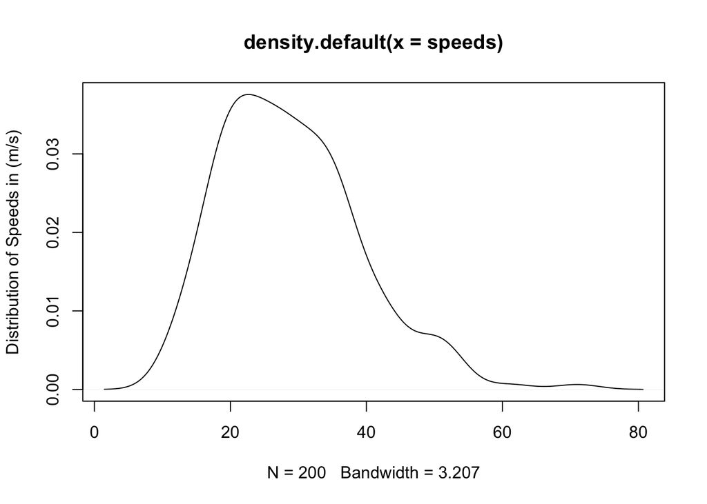

```r
plot(density(speeds), ylab="Distribution of Speeds in (m/s)")
```

```r
# how do we run each car for all speeds
# pmap runs a function for each value in a list of parameters, with other parameters set for each iteration


powerall2 = pmap(list(A = possible_cars$area, m=possible_cars$mass), autopower, V=speeds)

# lets turn to a data frame for easier graphing
# we can add column names
powerall2 = as.data.frame(powerall2, col.names=possible_cars$name)

# apply family of functions does this to - FYI
# what mapply does is run the function for each row in parameters listed, using values for other parameters listed in MoreArgs EACH time - a column for row in parameter list is returned
powerall2b = mapply(FUN=autopower, A = possible_cars$area, m=possible_cars$mass, MoreArgs = list(V=speeds)  )
# we can add column names
colnames(powerall2b)=possible_cars$name

head(powerall2b)
```

```
##              A         B         C         S
## [1,] 114775.35  358223.7  224735.1  53955.67
## [2,] 997056.99 1821608.8 1248900.5 457296.09
## [3,]  53142.52  213335.5  129934.5  25402.31
## [4,] 135765.25  401807.1  253880.6  63628.93
## [5,]  39460.46  174147.6  105060.6  19001.51
## [6,] 129250.81  388474.0  244940.4  60628.45
```

```r
head(powerall2)
```

```
##           A         B         C         S
## 1 114775.35  358223.7  224735.1  53955.67
## 2 997056.99 1821608.8 1248900.5 457296.09
## 3  53142.52  213335.5  129934.5  25402.31
## 4 135765.25  401807.1  253880.6  63628.93
## 5  39460.46  174147.6  105060.6  19001.51
## 6 129250.81  388474.0  244940.4  60628.45
```

```r
# for plotting sometimes its useful to turn columns in to rows
powerallr2 = powerall2 %>% pivot_longer(cols=everything(), names_to="car", values_to="power")
head(powerallr2)
```

```
## # A tibble: 6 × 2
##   car      power
##   <chr>    <dbl>
## 1 A      114775.
## 2 B      358224.
## 3 C      224735.
## 4 S       53956.
## 5 A      997057.
## 6 B     1821609.
```

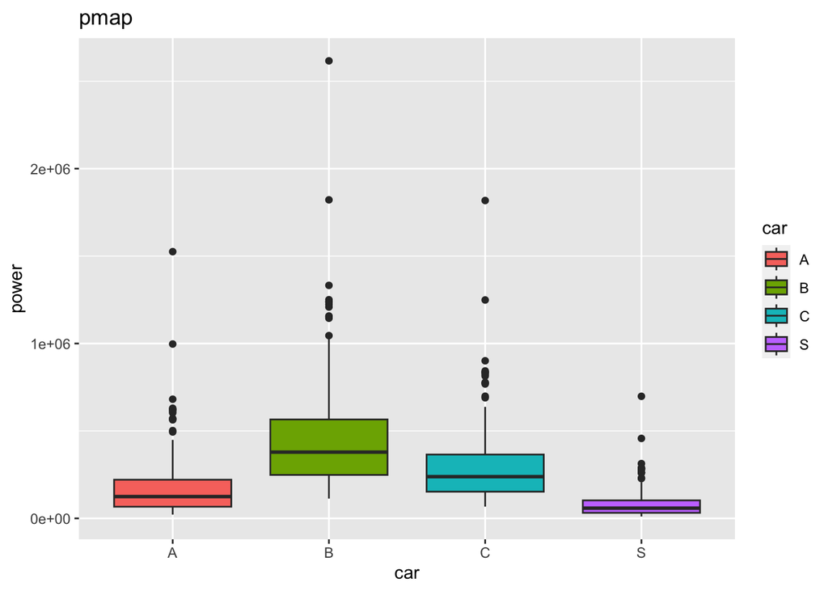

```r
# quick visualization

method2_plot = ggplot(powerallr2, aes(car,power, fill=car))+geom_boxplot()+ggtitle("pmap")
method2_plot
```

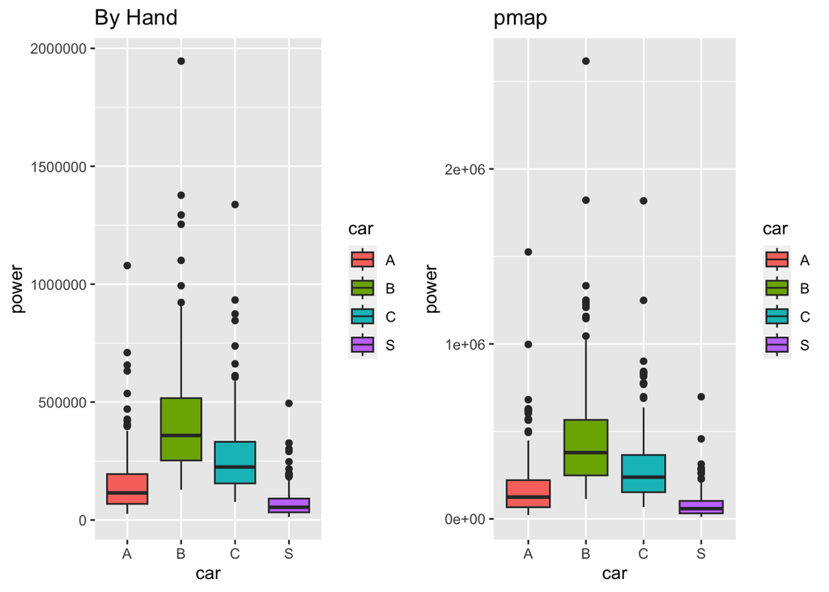

```r
# put plots side by side
# to confirm that they look similar
ggarrange(method1_plot, method2_plot)
```

```r
# compare values
head(powerallr2)
```

```
## # A tibble: 6 × 2
##   car      power
##   <chr>    <dbl>
## 1 A      114775.
## 2 B      358224.
## 3 C      224735.
## 4 S       53956.
## 5 A      997057.
## 6 B     1821609.
```

```r
head(powerallr1)
```

```
## # A tibble: 6 × 2
##   car     power
##   <chr>   <dbl>
## 1 A     204640.
## 2 B     535280.
## 3 C     344317.
## 4 S      95286.
## 5 A     137052.
## 6 B     404422.
```

```r
# not exactly the same - why?
# recall that we sample speeds!

# but we can compare means (also using  map :)
# map runs the function (here - mean), over each column
# they are close but still not exact, so statistics such as means and quantiles are # similar, and relative difference between cars is the same
powerall1 %>% map(mean)
```

```
## $A
## [1] 154729
##
## $B
## [1] 420998.5
##
## $C
## [1] 269209.3
##
## $S
## [1] 72189.8
```

```r
powerall2 %>% map(mean)
```

```
## $A
## [1] 177869.2
##
## $B
## [1] 460869.1
##
## $C
## [1] 296882.7
##
## $S
## [1] 82781.66
```

```r
# upper 90% quantile
powerall1 %>% map(quantile, probs=0.9)
```

```
## $A
##      90%
## 317767.4
##
## $B
##      90%
## 737361.7
##
## $C
##      90%
## 483510.9
##
## $S
##      90%
## 147130.4
```

```r
powerall2 %>% map(quantile, probs=0.9)
```

```
## $A
##      90%
## 360230.1
##
## $B
##    90%
## 810048
##
## $C
##      90%
## 534032.1
##
## $S
##      90%
## 166562.4
```

# Third - classic looping *for*

*pmap* works quickly but it is unique to R Other programming language (and R) use what are called loops - where repetition is more explicit

Lets do this one more time using a *for* loop

```r
# the first part, generating speeds is the same
# what is I want to estimate average power use given  each car

possible_cars
```

```
##   name  mass area     power
## 1    A 10000   22  77436.12
## 2    B 65000   30 274724.89
## 3    C 38000   22 169634.52
## 4    S  5000   10  36694.96
```

```r
# use sample to generate a distribution of speeds

# assume a log normal distribution of speeds with mean 80km/hr
# recall our function needs speed in m/s not km/hr so we will also do a conversion
# lets get a sample of a 200 speeds- we could also do this by actually measuring speeds

nsample = 200
mean_speed = log(100*0.277)

speeds = rlnorm(mean=mean_speed, sd=0.1*mean_speed, nsample)
summary(speeds)
```

```
##    Min. 1st Qu.  Median    Mean 3rd Qu.    Max.
##   11.40   22.44   28.13   29.13   34.71   60.36
```

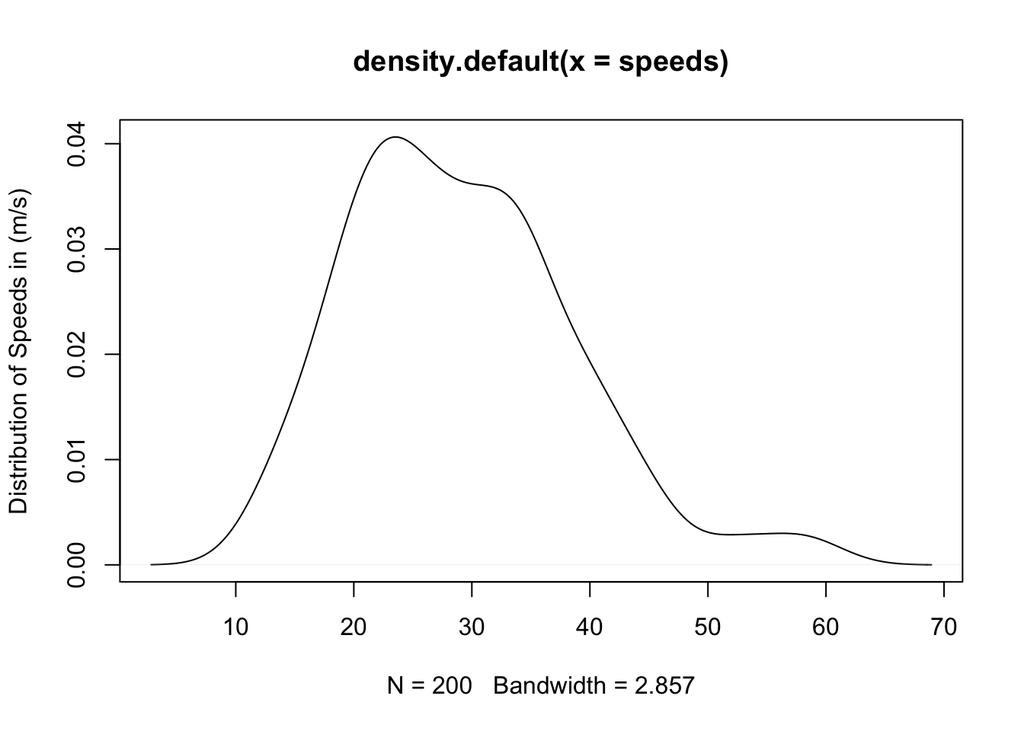

```r
plot(density(speeds), ylab="Distribution of Speeds in (m/s)")
```

```r
# how do we run each car for all speeds
# we use a for loop to cycle through
# we need to create a data frame to store results - as above
# one column for each car and one row for each speed

powerall3 = as.data.frame(matrix(nrow=length(speeds), ncol=nrow(possible_cars)))
# because we don't initialize it - values are NA
head(powerall3)
```

```
##   V1 V2 V3 V4
## 1 NA NA NA NA
## 2 NA NA NA NA
## 3 NA NA NA NA
## 4 NA NA NA NA
## 5 NA NA NA NA
## 6 NA NA NA NA
```

```r
# how many cars area there
nrow(possible_cars)
```

```
## [1] 4
```

```r
# for loops use an index - in this case "i" but you could use anything - it repeats
# anything between the {} for each values of i between 1 and nrow(possible_car) (which is 3 in our case)

# index in to a matrix (like powerall3) is by row and column powerall3[2,5] is 2nd row and 5th column
for (i in 1:nrow(possible_cars)) {
  powerall3[,i] = autopower(A=possible_cars$area[i], m=possible_cars$mass[i], V=speeds)
}

# now it looks like above
head(powerall3)
```

```
##         V1       V2       V3        V4
## 1 190331.6 508451.7 326019.8  88717.10
## 2 430859.5 928442.6 616699.0 198862.08
## 3 411330.4 895978.4 593989.9 189933.64
## 4 125196.6 380092.6 239331.0  58760.38
## 5 127248.9 384343.7 242175.1  59706.09
## 6 124125.2 377866.4 237842.5  58266.61
```

```r
# we can add column names
colnames(powerall3)=possible_cars$name

# plotting is the same as above

# for plotting sometimes its useful to turn columns in to rows
powerallr3 = powerall3 %>% pivot_longer(cols=everything(), names_to="car", values_to="power")
head(powerallr3)
```

```
## # A tibble: 6 × 2
##   car     power
##   <chr>   <dbl>
## 1 A     190332.
## 2 B     508452.
## 3 C     326020.
## 4 S      88717.
## 5 A     430859.
## 6 B     928443.
```

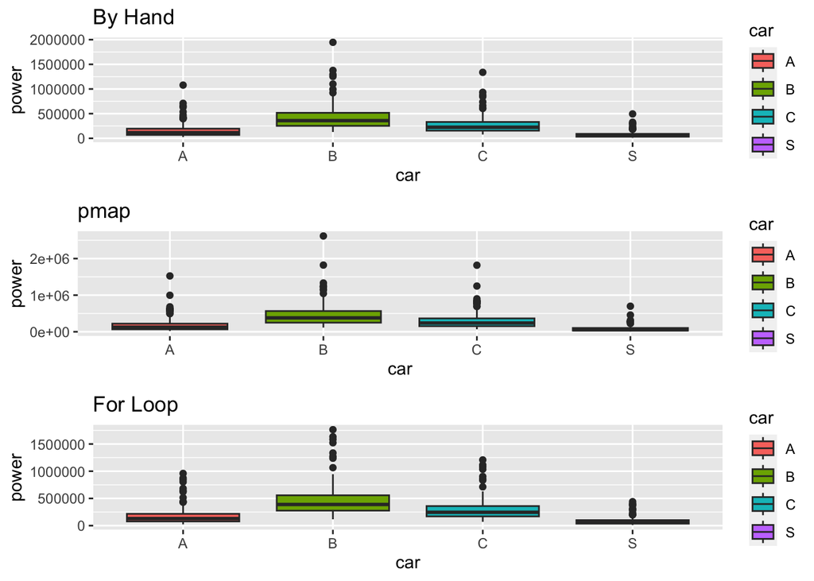

```r
# quick visualization
method3_plot = ggplot(powerallr3, aes(car,power, fill=car))+geom_boxplot()+ggtitle("For Loop")

ggarrange(method1_plot, method2_plot, method3_plot, nrow=3)
```

```r
powerall1 %>% map(mean)
```

```
## $A
## [1] 154729
##
## $B
## [1] 420998.5
##
## $C
## [1] 269209.3
##
## $S
## [1] 72189.8
```

```r
powerall2 %>% map(mean)
```

```
## $A
## [1] 177869.2
##
## $B
## [1] 460869.1
##
## $C
## [1] 296882.7
##
## $S
## [1] 82781.66
```

```r
powerall3 %>% map(mean)
```

```
## $A
## [1] 174655.3
##
## $B
## [1] 458108.2
##
## $C
## [1] 294552.8
##
## $S
## [1] 81335.16
```